# MTH 138, Class Week 3

## Percentiles, quartiles, boxplots, oh my!

The harder direction involves asking for a certain percentile of a measurement. For example, what is the 85th percentile for the `crim` measurement?

We rely on the `quantile()` command to find these quickly. To use this properly, you first put your data vector, then pass the percentile you want in next *as a decimal*. Let’s find the 80th percentile of the `crim` variable:

```r
#Place code here
# ?quantile
quantile(boston2$crim, .8)
```

```
    80%
5.58107
```

We can compute a bunch of percentiles at once by passing a vector of probabilities into the `probs =` argument. For example, try putting `c(.1, .25, .5, .75, .9)` into that argument:

```r
# Place code here.
quantile(boston2$crim, c(.1, .25, .5, .75, .9))
```

```
      10%       25%       50%       75%       90%
 0.038195  0.082045  0.256510  3.677083 10.753000
```

**Quartiles** are a fancy way of referring to the 25th, 50th, and 75th percentiles. Specifically,

- The first quartile $Q_1$ is the same as the 25th percentile $P_{25}$
- The first quartile $Q_2$ is the same as the 50th percentile $P_{50}$ (also the median)
- The first quartile $Q_3$ is the same as the 75th percentile $P_{75}$

Do you remember a command that gives the quartiles after passing in a quantitative vector?

```r
#  take your guess!
summary(boston2$crim)
```

```
    Min.  1st Qu.   Median     Mean  3rd Qu.     Max.
 0.00632  0.08204  0.25651  3.61352  3.67708 88.97620
```

Lastly, a common visualization when comparing quantitative data between groups is a boxplot.

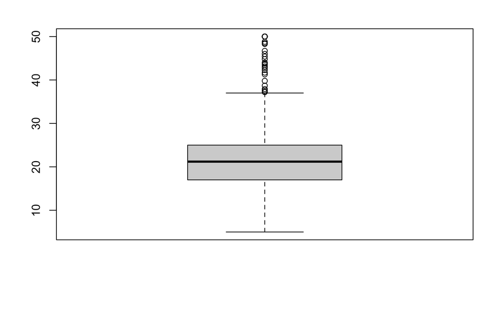

```r
boxplot(boston2$medv)
```

It is much more common to use “comparative boxplots,” where one produces side-by-side boxplots of a quantitative variable comparing two or more groups.

Recall that the `chas` variable indicates whether a Boston Suburb in the data frame is located along the Charles River (0 means “No”, and 1 means “Yes”). The code below compares the median value of homes between these two groups using comparative boxplots.

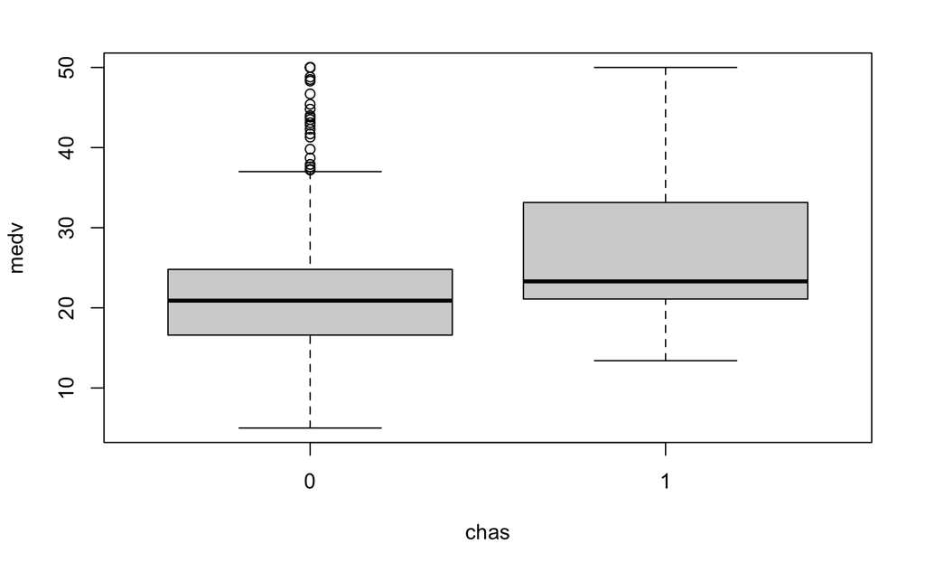

```r
boxplot(medv ~ chas, data = boston2)
```

Try this out on your own. Compare the `tax` variable using the `chas` variable to create your groups.

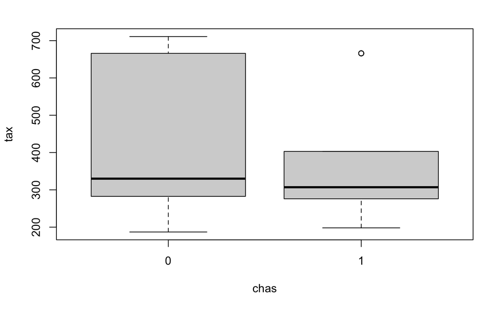

### Is there time to play?

Let’s play!

Quick data frame slicing using `dplyr`

- to get specific columns, use `select()`
- to get specific rows, use `filter()`
  - inputs to the filter command are *logical vectors*

Let’s create a data frame that looks at the `chas` and `medv` variables, but only includes rows where the `medv` is greater than the mean-value for that variable.

```r
# data frame

# filter rows

# select columns

Boston %>%
    filter(medv > mean(medv)) %>%
    select(medv, chas)
```

| medv | chas |
| --- | --- |
| 24.0 | 0 |
| 34.7 | 0 |
| 33.4 | 0 |
| 36.2 | 0 |
| 28.7 | 0 |
| 22.9 | 0 |
| 27.1 | 0 |
| 23.1 | 0 |
| 24.7 | 0 |
| 30.8 | 0 |

[output cut: 199 more lines]

```r
NA
```

```r
iris %>%
    filter(Species=="setosa",
           Petal.Length > 1.35) %>%
    select(Petal.Length, Sepal.Length, Species)
```

| Petal.Length | Sepal.Length | Species |
| --- | --- | --- |
| 1.4 | 5.1 | setosa |
| 1.4 | 4.9 | setosa |
| 1.5 | 4.6 | setosa |
| 1.4 | 5.0 | setosa |
| 1.7 | 5.4 | setosa |
| 1.4 | 4.6 | setosa |
| 1.5 | 5.0 | setosa |
| 1.4 | 4.4 | setosa |
| 1.5 | 4.9 | setosa |
| 1.5 | 5.4 | setosa |

[output cut: 29 more lines]